[figure not shown]

# IFSC Worlld Cup Bouldering Analysis

The International Federation of Sport Climbing ([IFSC](https://www.ifsc-climbing.org/)) was founded in 2007 with the goal of encouraging, promoting, and developing the sport of climbing worldwide. With its addition to the most recent [Summer Olympics](https://olympics.com/en/sports/sport-climbing/), climbing in general has seen a huge spike in interest. Speed climbing in particular has taken the title of "Fastest Sport" in the Olympic games, with the fastest time of just barely over 5 seconds! But this project isn't going to focus on speed - rather, it's going to focus on the wonderful discipline of bouldering.

Bouldering is rock climbing in its purest form. No ropes, no harnesses - just you and the wall. With bouldering being one of the more accessible disciplines in climbing (the others being lead and speed), it's no surprise that it's rapidly growing in popularity worldwide. All you need is a pair of climbing shoes, some chalk, and a willingness to push yourself to your absolute limits.

## Project Goals

In this analysis, I aim to help shed some light on boulderers from around the world. I have scraped the results from the IFSC website for all of the World Cup Events from 2007 to present day in the hopes of answering the following questions:

- Who are the most successful climbers?
  - Who has the most gold medals?
  - Which climbers have made it to the finals the most?
- Which country produces the best climbers?
  - Are any countries more dominant than others?
- How have climbers performed over time?
  - Do any climbers stand out from the rest?

I am to update this every time a new event takes place, so that the results and the analysis are as up-to-date as possible.

## Combining the Data

[output not shown]

[output not shown]

```
JONGWON CHON appearances:
Qualification round:  47
   Semi-Final round:  42
        Final round:  26
```

As seen above, Jongwon Chon has appeared in 47 qualification rounds, and astounding has made it to 26 finals! That's incredibly impressive considering how difficult it is to consistently perform at such a high level!

# Climber Statistics

## Individual Climber Results

Now we can look at the entirety of the results for men's bouldering (the exact same process can be followed for women's bouldering). The following function first checks to see if we have a .csv file that contains all of the data already. If we do, it loads it. If not, then it creates a new one - though it does take some time because it does require a complete scrape of the IFSC site to try and get each climber's height.

[output not shown]

As you can see from the above, from our original ~7880 rows, we have condensed it down to just over 1300 unique male climbers. Along with their respective countries of origin, you can see the number of times each climber appeared in the qualification, semi-final, and final rounds. Additionally, you can see a percentage of times the climber reached that specific round. We're not done yet however, as there is still some important information we can figure out.

## Podium Count

How many times did each climber reach the podium? How many Bronze, Silver, or Gold medals did they get? Now that we have all of the data in a single dataframe, we can find out! To do this, we can use the [.groupby](https://pandas.pydata.org/docs/reference/api/pandas.DataFrame.groupby.html) method, as well as a clever use of the .size and .unstack methods.

[output not shown]

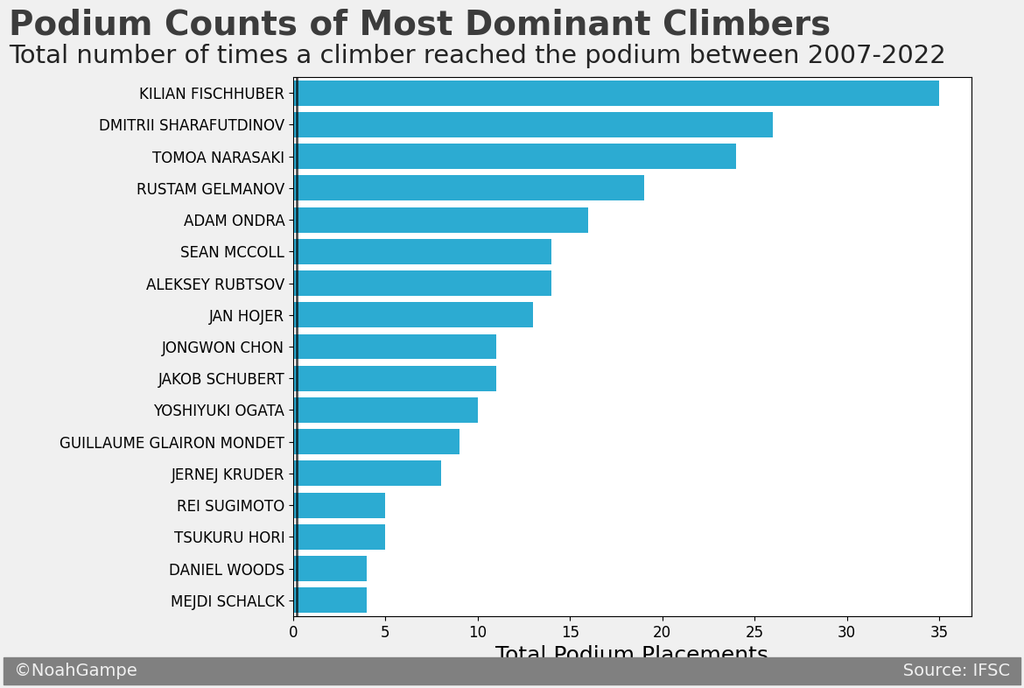

Now we have a more robust dataframe with more relevant information. Additionally, we can use this dataframe with our previous function to check out a single climber and see all their stats. A reminder that these stats only represent the IFSC World Cup events.

|  | ID | Name | Country | Qualification | Semi-Final | Final | Podium | Bronze | Silver | Gold | Q_Pct | S_Pct | F_Pct | P_Pct | Bronze_Pct | Silver_Pct | Gold_Pct |
| --- | --- | --- | --- | --- | --- | --- | --- | --- | --- | --- | --- | --- | --- | --- | --- | --- | --- |
| 0 | 2052 | JONGWON CHON | KOR | 47 | 42 | 26 | 11 | 3 | 3 | 5 | 100.0 | 89.36 | 55.32 | 23.4 | 6.38 | 6.38 | 10.64 |

## Country Statistics

[output not shown]

Above we can see a table that details how many times a climber from a given country participated in a specific round. Right away we can see that Japan has had the most number of climbers participate in Qualification rounds *and* Finals. Similar to before, we can add some more detail to this chart to get the number of times a country achieved a podium position.

[output not shown]

Looking at the above table, we can quickly see that Russia, Austria, and Japan have the most number of gold medals *by far*. In fact, they have the most Bronze and Silver medals too! Clearly, these three countries are doing something right with their climbers training regimens. To put it into perspective visually, the below chart shows just how far ahead the three countries are in terms of podium placements.

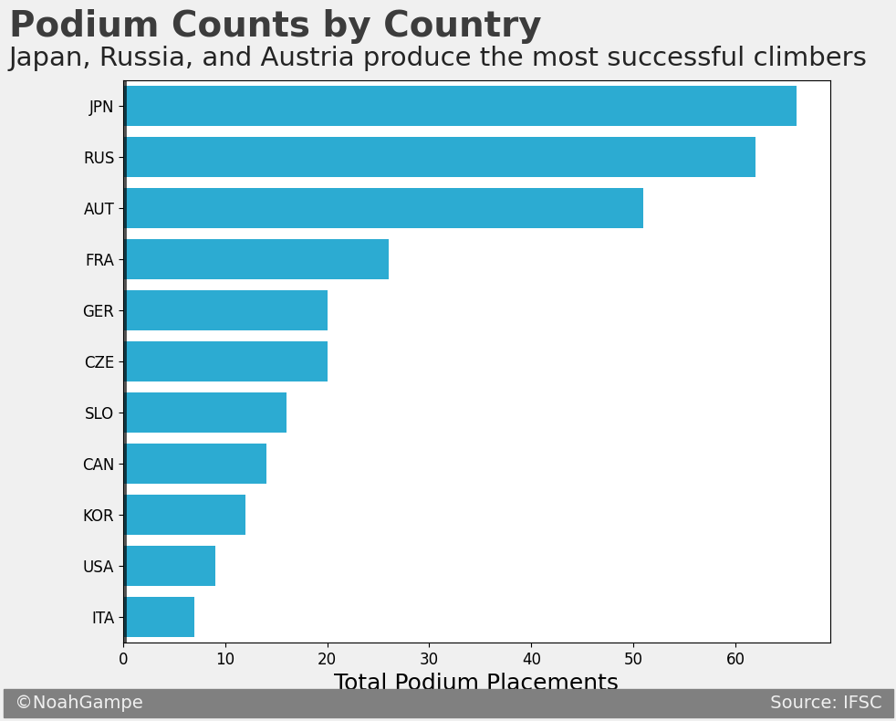

## Country Performance Over Time

Which countries had the strongest performance over time? We can create a new dataframe, one that shows the number of times a climber from a given country reached the final round of a world cup event per year. According to [section 8.6 of the IFSC Rules](https://cdn.ifsc-climbing.org/images/Website/2023_IFSC_Rules_112.pdf), the quota for the Final round shall be six (6) climbers. To properly view all climbers who made it to the final round, we shall be looking at all climbers who have a rank less than or equal to 6.

[output not shown]

The above dataframe contains the number of finalists per country, per year. We will make a visualization of this in a second. We can sum up the totals over all the years to see which country produces the most IFSC World Cup finalists.

[output not shown]

## Number of Finalists Per Country Over Time

[interactive chart not shown]

If we examine the above results, it's very clear that Japan and Russia dominate bouldering competitions (in terms of the number of times one of their climbers reached the finals). Fascinatingly, Japan has reached the finals round at least once per year for every single year except 2020 - which was right in the middle of the COVID-19 pandemic, when the [IFSC cancelled two competition events](https://www.ifsc-climbing.org/index.php/news/388-ifsc-world-cups-in-salt-lake-city-and-seoul-cancelled) due to health and safety concerns. This resulted in 2020 only have a *single* bouldering event for the entire season. That one event was the European Continental Championships, so non-Europeans weren't allowed to compete anyways!

## Plotly Graph Function

Below we create a basic plotly graph that allows us to pass in a dataframe and a column, and it will generate an interactive plotly chart that let's us filter the data and see the visualization.

## Top Climbers By Year

[interactive chart not shown]

## Top Climbers By Country

[interactive chart not shown]

## Individual Finals Appearances Over Time

[interactive chart not shown]

### Observations

There are clearly some climbers who have performed well for an extended period of time:

- Kilian Fischhuber
- Dmitrii Sharafutdinov
- Rustam Gelmanov
- Sean McColl
- Adam Ondra
- Aleksey Rubtsov
- Jakob Schubert
- Jan Hojer
- Jongwon Chon
- Tomoa Narasaki
- Kokoro Fujii
- Yoshiyuki Ogata

All of the above climbers have either appeared in finals for over 10+ years, or have appeared in a large number of finals. Currently, it does seem like climbers from Japan are performing better for longer periods of time.